# Althoff_IFN

Monica Ransom

10/8/2021

This analysis is to look at why Scribble KO HSC are insensitive to activating signals from interferon. To understand this WT and Scibble KO mice are treated or not with PolyIC an interferon stimulator. There are 4 groups here with WT, KO, WTIC, and KOIC. There are 3 mice with untreated condition and 4 mice per treated condition.

# Pre-processing

1. Adapters were trimmed with FASTP 0.21.0
2. Gene expression was quantified using salmon v1.3.0
3. TPMs were obtained for the genes using tximport 1.20.0

```r
library(ggplot2)
library(DESeq2)
library(tximport)
library(readr)
library(tximportData)
library(readxl)
library(knitr)
library(tidyverse)
library(pheatmap)
library(RColorBrewer)
library(viridis)
library(ggrepel)
library(EnhancedVolcano)
library(fgsea)
library(limma)
library(VennDiagram)
library(UpSetR)
library(wesanderson)
library(kableExtra)
library(reshape)
library(dplyr)
```

# Load metrics

```
## * `` -> ...1
```

Summary of Data Metrics

| samples | reads before trim | reads after trim | %Q30 | duplication | % of reads with adapter | Insert size | percent aligned | splices annotated | salmon percent aligned |
| --- | --- | --- | --- | --- | --- | --- | --- | --- | --- |
| WT_rep1 | 61002551 | 60449791 | 92.4929 | 12.0915 | 9.561156 | 118 | 78.64 | 9198083 | 59.6994 |
| WT_rep2 | 59366695 | 58759406 | 91.5568 | 11.6178 | 8.725623 | 119 | 79.87 | 10097467 | 62.0906 |
| WT_rep3 | 70194654 | 69436669 | 92.0470 | 12.9095 | 8.320139 | 119 | 79.59 | 11066266 | 62.8137 |
| KO_rep1 | 63782461 | 63126127 | 91.7028 | 12.4218 | 1.109101 | 119 | 72.87 | 8375861 | 51.9990 |
| KO_rep2 | 66128187 | 65388713 | 91.3069 | 13.5671 | 8.849251 | 117 | 77.00 | 8346970 | 56.2829 |
| KO_rep3 | 63880365 | 63168300 | 91.0102 | 13.0646 | 12.360554 | 119 | 71.95 | 8921300 | 56.4861 |
| WTIC_rep1 | 41050763 | 40183636 | 90.1762 | 13.9266 | 3.044598 | 119 | 80.23 | 5500867 | 53.5136 |
| WTIC_rep2 | 39474990 | 38752578 | 91.7329 | 12.6450 | 4.681941 | 119 | 81.57 | 5055002 | 52.9577 |
| WTIC_rep3 | 38524980 | 37699529 | 89.4794 | 14.3038 | 3.207358 | 118 | 79.34 | 5343450 | 55.9974 |
| WTIC_rep4 | 37942449 | 37173849 | 90.6850 | 12.4860 | 3.233808 | 119 | 80.16 | 4726578 | 52.9712 |
| KOIC_rep1 | 41161158 | 40368325 | 91.3712 | 14.3709 | 3.844799 | 117 | 80.44 | 4962629 | 52.4011 |
| KOIC_rep2 | 40345747 | 39535690 | 90.9779 | 13.8305 | 3.955074 | 119 | 80.05 | 5199790 | 53.6240 |
| KOIC_rep3 | 43540976 | 42726703 | 91.7218 | 14.2954 | 3.428689 | 119 | 80.06 | 5860118 | 55.7803 |
| KOIC_rep4 | 41799389 | 40956452 | 90.8947 | 14.8623 | 3.349685 | 119 | 80.46 | 4838976 | 52.2488 |

This table shows that there was reasonable duplication rates in these samples. The insert size is smaller and it aligns better with STAR than Salmon. Many of the reads were adapter trimmed pretty extensively and both this and duplication rate probably lowered the Salmon alignment rate.

## Summary of Data prior to analysis

Metadata Table

| Sample | Mouse_genotype | treatment |
| --- | --- | --- |
| WT_rep1 | WT | none |
| WT_rep2 | WT | none |
| WT_rep3 | WT | none |
| KO_rep1 | KO | none |
| KO_rep2 | KO | none |
| KO_rep3 | KO | none |
| WTIC_rep1 | WT | PolyIC |
| WTIC_rep2 | WT | PolyIC |
| WTIC_rep3 | WT | PolyIC |
| WTIC_rep4 | WT | PolyIC |
| KOIC_rep1 | KO | PolyIC |
| KOIC_rep2 | KO | PolyIC |
| KOIC_rep3 | KO | PolyIC |
| KOIC_rep4 | KO | PolyIC |

# Calculate the number of genes with greater than 5 counts in all samples

There are 6819 genes with greater than 5 counts in all samples.

## Sample Heatmap and Correlation matrix

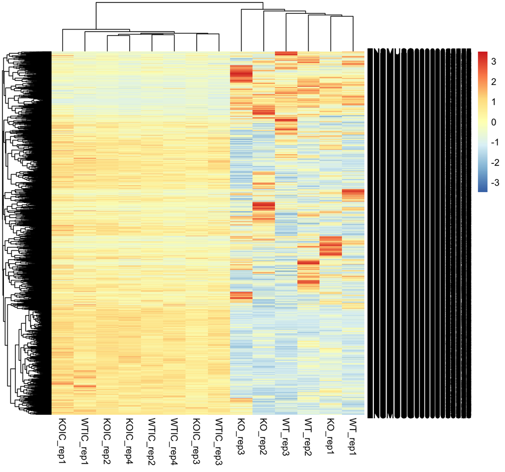

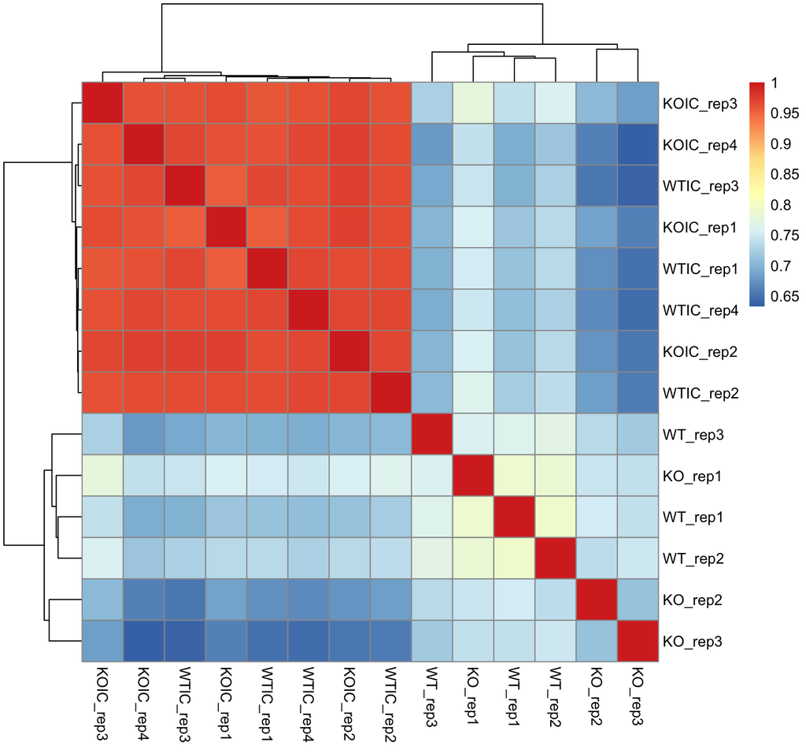

We see high correlation between all samples that were treated regardless of phenotype. In the untreated samples there was less correlation this may be due to the mouse variability.

# PCA plot of non-normalized data

### PC1 vs PC2

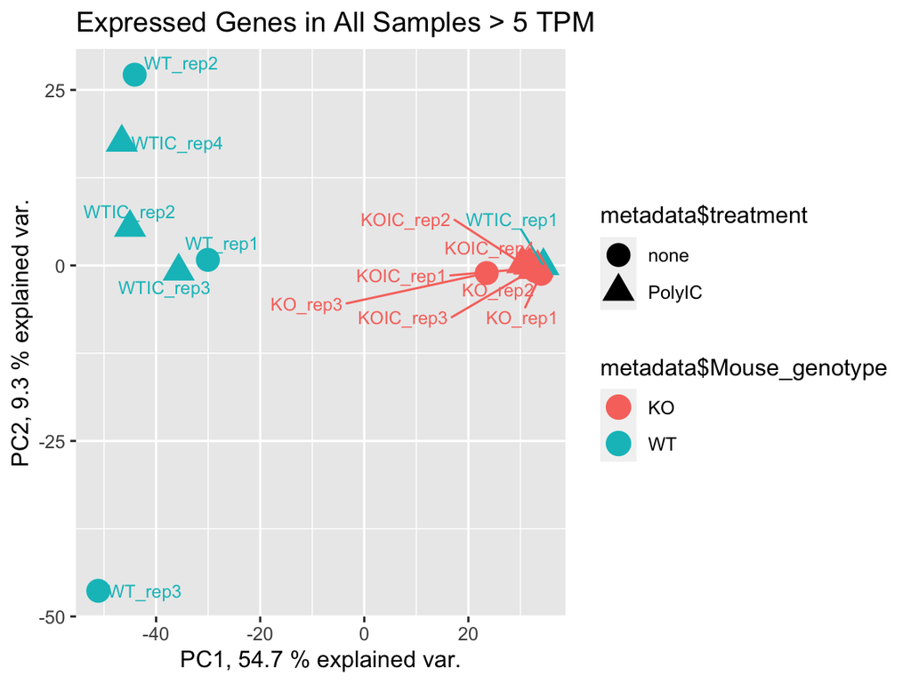

This doesn’t seem to match the correlation data which indicated that the treated samples were more similar to each other.

## Run Differential Expression testing using DESeq2 and Calculate Gene Set Enrichment

### Compare WTvKO, WTvWTIC, KOvKOIC, WTICvKOIC

#### sig = padj <0.01 and abs(l2fc) >0.5

```r
kable(significant_genes)
```

| comparison | sig.genes |
| --- | --- |
| WTvsWTIC | 4316 |
| WTvKO | 1157 |
| WTICvKOIC | 24 |
| KOvKOIC | 4347 |

```r
DEG_WTvKO<-as.data.frame(res_WTvKO) %>%
  filter(padj<.01 & abs(log2FoldChange) >= .5)%>%
  rownames_to_column(var="ensembl_gene_id")%>%
  left_join(ens2gene,by="ensembl_gene_id")%>%
  select(Gene, padj, pvalue, log2FoldChange)%>%
  arrange(padj)


DEG_WTvWTIC<-as.data.frame(res_WTvWTIC)%>%
  filter(padj<.01 & abs(log2FoldChange) >= .5)%>%
  rownames_to_column(var="ensembl_gene_id")%>%
  left_join(ens2gene,by="ensembl_gene_id")%>%
  select(Gene, padj, pvalue, log2FoldChange)%>%
  arrange(padj)

DEG_WTICvKOIC<-as.data.frame(res_WTICvKOIC)%>%
  filter(padj<.01 & abs(log2FoldChange) >= .5)%>%
  rownames_to_column(var="ensembl_gene_id")%>%
  left_join(ens2gene,by="ensembl_gene_id")%>%
  select(Gene, padj, pvalue, log2FoldChange)%>%
  arrange(padj)

DEG_KOvKOIC<-as.data.frame(res_KOvKOIC)%>%
  filter(padj<.01 & abs(log2FoldChange) >= .5)%>%
  rownames_to_column(var="ensembl_gene_id")%>%
  left_join(ens2gene,by="ensembl_gene_id")%>%
  select(Gene, padj, pvalue, log2FoldChange)%>%
  arrange(padj)
```

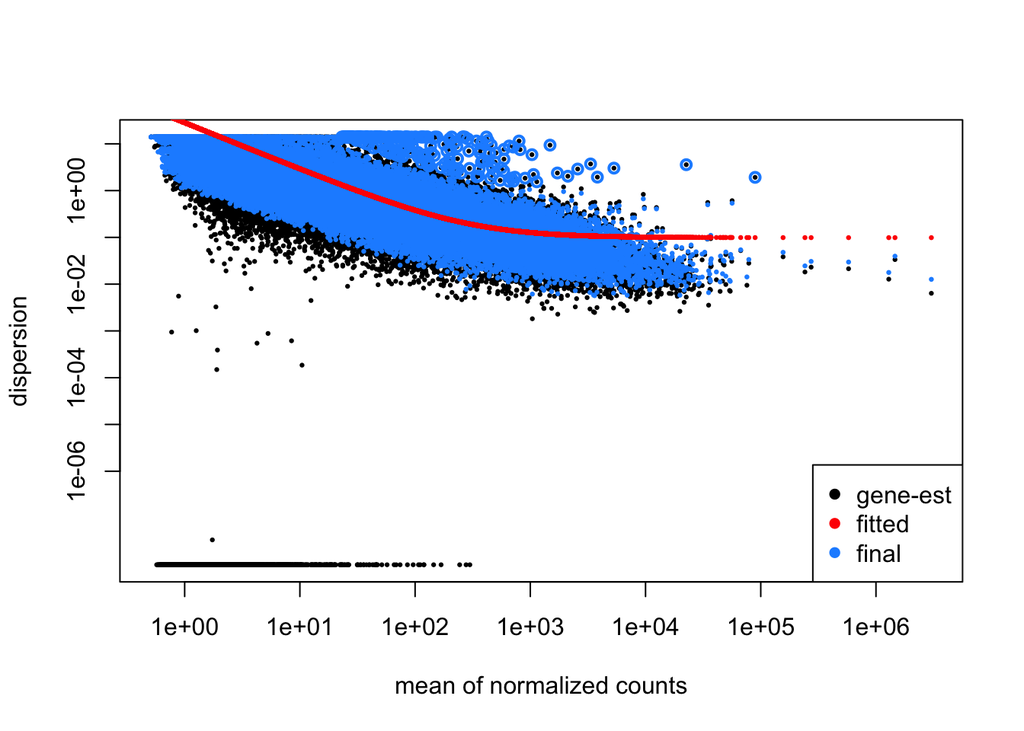

```r
plotDispEsts(dds.filtered)
```

## Top 20 DEG plots

```r
top_20_WTvKO<-DEG_WTvKO[1:20, 1]
```